# The structure of the conectivity data, and how to plot basic connectivity

James Pringle

2023-05-17

Lets load the data saved in `03_GetData_Subset_and_Combine.Rmd` and examine how connectivity is represented in the data.frame.

```r
E<-readRDS('mayJuneEastCoast_connectivity.RDS')
```

Before starting to plot the connectivity data, it is useful to load the `rnaturalfeatures` data that provides coastline data, along with the simple features library `sf` which provides functions to define geometric features and the `ggplot2` plotting library.

```r
    library(sf)
```

```r
    library(ggplot2)
    library("rnaturalearth")
    library("rnaturalearthdata")
    world <- ne_countries(scale = "medium", returnclass = "sf") #get coastline data
    class(world)
```

```
## [1] "sf"         "data.frame"
```

# Plot starting locations

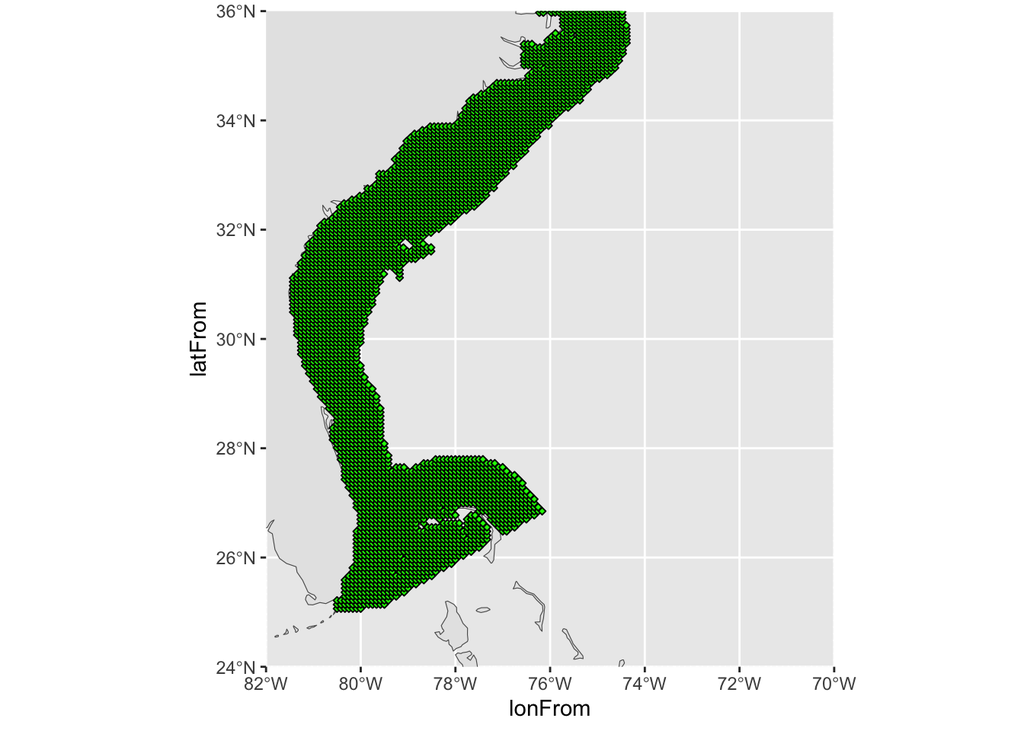

```r
    p<-ggplot(data = world) + geom_sf() +
      coord_sf(xlim= c(-82, -70), ylim = c(24, 36), expand = FALSE)+
      geom_point(data = E, aes(x = lonFrom, y = latFrom), size = 1, shape = 23, fill = "green",color='black')
    print(p) #this makes the figure appear
```

# Plot where particles go

Now lets look at where all the particles released in a small region go in the 18 day drifting duration of this data. First, define a polygon that encompasses the region where the particles are released:

```r
  #define limits of a box that defines the release locations
  lonLimits=c(-82.0,-80) #longitude of corners
  latLimits=c(28.0,30.0) #latitude of corners
  limitPoly=st_polygon(list(cbind(lonLimits[c(1,2,2,1,1)],latLimits[c(1,1,2,2,1)])))
  limitPoly<-st_sfc(limitPoly,crs=4326) #make into a surface, 4326 is WGS84
```

Now further subset E to only include particle starting location. Set `trimTo` to `FALSE` so we also include particles that leave the starting locations. Because `subsetConnectivity_byPolygon()` comes from the `connectivityUtilities.R`, we must source `connectivityUtilities.R` to load the functions in it.

```r
  #subset connectivity data
  source('connectivityUtilities.R')
```

```
## [1] "file connectivityData/EZfateFiles/model_depth_and_distance.nc exists, no download"
```

```r
  EstartPoints<-subsetConnectivity_byPolygon(E,limitPoly,trimTo=FALSE)
```

Now combine each row in `EstartPoints` and make a data.frame with each location particles get to, and the total number of particles that get there.

```r
    allTo<-data.frame(lonTo=c(EstartPoints$lonTo,recursive=TRUE),
                      latTo=c(EstartPoints$latTo,recursive=TRUE),
                      numTo=c(EstartPoints$numTo,recursive=TRUE))
```

and them add together the total number of points that get to the same `(lonTo,latTo)` points

```r
    whereAllWent<-allTo %>% group_by(lonTo,latTo) %>% summarise(numTo=sum(numTo))
```

`numTo` in `whereAllWent` is the number of points that got to each destination location. It is often better to know the fraction of points launched that go to each point. `sum(EstartPoints$numLaunched)` gives the total number of particles launched, and so we can use it to calculate the fraction of particles that go to each point:

```r
    whereAllWent$fracTo<-whereAllWent$numTo/sum(EstartPoints$numLaunched)
```

and now we can plot the starting points from `(EstartPoints$lonFrom,EstartPoints$latFrom)` in bright green and the `log10(density)` of where particles released from those points ended up with `log10(whereAllWent$fracTo)`. :

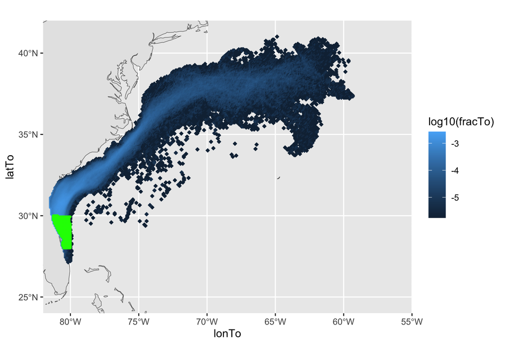

```r
    p<-ggplot(data = world) + geom_sf() +
      coord_sf(xlim= c(-82, -55), ylim = c(24, 42), expand = FALSE)
    #p<-p+geom_point(data = EstartPoints, aes(x = lonFrom, y = latFrom), size = 1, shape = 23, fill = "green",color='black')
    p<-p+geom_point(data = whereAllWent, aes(x = lonTo, y = latTo, fill=log10(fracTo),colour=log10(fracTo)), size = 1, shape = 23)
    p<-p+geom_point(data = EstartPoints, aes(x = lonFrom, y = latFrom), size = 0.5, shape = 23, fill = "green",color='green')
    print(p) #this makes the figure appear
```

Often we will want to model the dispersal of an organism over multiple generations, or something similar. Let us, for now, imagine modeling a semelparous organism, and imagine it starts at a specific point, and each generation it will release a certain number of larvae. Where will those larvae end up, and how many will make it?

**In the next section connectivity data will be used to quantitatively examine the spread of an organism from an initial location over multiple generations.**